# 张嘉辰_2018201743_统计软件第4次作业

张嘉辰

2020年11月13日

# 任务一

```r
library(readxl)
library(tibble)
#读入xlsx格式的数据，为tibble类型
jobinfo <- read_xlsx("D:/data/jobinfo.xlsx", col_names = TRUE)
#查看数据结构
str(jobinfo)
```

```
## tibble [7,389 x 12] (S3: tbl_df/tbl/data.frame)
##  $ 职位    : chr [1:7389] "万向联合诚聘金融交易助理/数据分析 期待你的加入" "数据分析师" "QA  数据分析" "数据分析师 (职位编号：yunshan002894)" ...
##  $ 公司名称: chr [1:7389] "北京万向联合控股集团有限公司" "酷我音乐" "北京互联企信信息技术有限公司" "美菜网" ...
##  $ 地区    : chr [1:7389] "北京" "北京" "北京" "北京" ...
##  $ 公司类别: chr [1:7389] "合资" "外资" "外资" "外资" ...
##  $ 公司规模: chr [1:7389] "150-500人" "150-500人" "1000-5000人" "1000-5000人" ...
##  $ 行业类别: chr [1:7389] "金融/投资/证券" "互联网/电子商务" "外包服务" "互联网/电子商务" ...
##  $ 经验    : num [1:7389] 0 3 0 3 3 0 3 2 0 0 ...
##  $ 学历    : chr [1:7389] "本科" "无" "大专" "大专" ...
##  $ 人数    : chr [1:7389] "招聘10人" "招聘1人" "招聘1人" "招聘1人" ...
##  $ 描述    : chr [1:7389] "想要付出多少努力 便已经定格好要赚多少钱 l 每个月薪资 随随便便找一个文职工作就可以了 l 每个月薪资 只要加一点班就"| __truncated__ "岗位职责 根据需求收集数据 日常数据整理 分析 对线上业务需求建立相应的数据模型 各部门数据支持 任职要求 了解互联网"| __truncated__ "岗位职责 进行日常 周度 月度 季度数据分析 负责呼叫中心质检部门 整体运营报表的 整合数据资源 确保呼叫中心日常数据"| __truncated__ "岗位职责 根据业务量数据合理预算人员需求 提高人效 控制客服中心成本使用 通过提…
##  $ 最低薪资: chr [1:7389] "8000" "10000" "4500" "6000" ...
##  $ 最高薪资: chr [1:7389] "9999" "14999" "5999" "10000" ...
```

```r
#将数据集中的最高薪资和最低薪资以数值型变量保存
min_salary <- as.numeric(jobinfo$最低薪资)
max_salary <- as.numeric(jobinfo$最高薪资)
#由于缺失数据的存在，会出现警告
#Warning message:
#NAs introduced by coercion
```

# 任务二

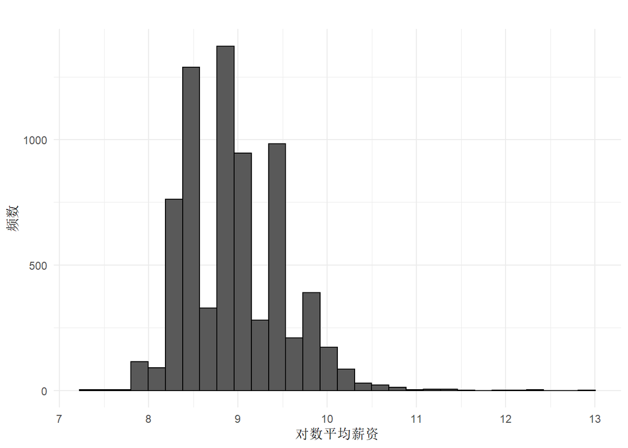

```r
#计算对数平均薪资
log_salary <- log((min_salary + max_salary)/2)

#在jobinfo中添加对数平均薪资
jobinfo$对数平均薪资 <- log_salary

library(ggplot2)
library(hrbrthemes)
#构建对数平均薪资的数据框
df_log_salary <- data.frame(log_salary)
#绘制对数平均薪资的分布直方图
ggplot(df_log_salary, aes(log_salary))+
#共分30组
  geom_histogram(bins = 30,
    color = "black") +
  theme_minimal() +
  labs(x = "对数平均薪资", y = "频数", title = "")
```

可以从直方图上看到，对数平均薪资的分布比较接近对称和正态。

因此，通过对最低薪资和最高薪资进行平均后再取对数的变换，可以使原本右偏的数据更接近正态，有利于回归模型的建立。

# 任务三

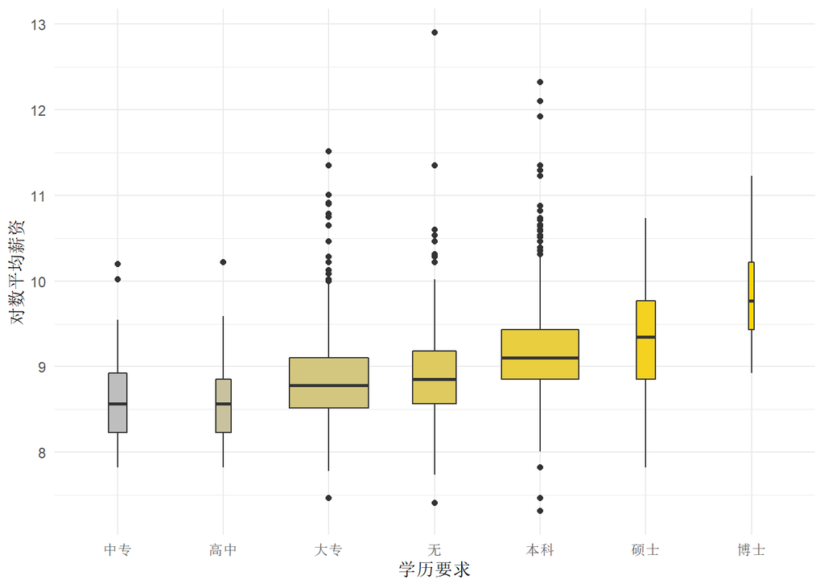

```r
library(hrbrthemes)

#因子类型，而且为有序的
edu <- factor(jobinfo$学历, levels = c("中专","高中","大专","无","本科","硕士","博士"), order = TRUE)

#构建包含对数平均薪资和学历的数据框
df_salary_edu <- data.frame(log_salary, edu)

#colors_fill为从灰色到金色的7个渐变色，将依次作为7个箱子的颜色
colors_fill <- colorRampPalette(c("grey", "gold"))(7)

#画出各类学历的对数平均薪资箱线图
ggplot(df_salary_edu, aes(x = edu, y = log_salary, fill = edu)) +
#varwidth参数设置为TRUE，使箱子的水平宽度代表要求该学历的公司岗位数量
  geom_boxplot(varwidth = TRUE, fill = colors_fill) +
  theme_minimal() +
  labs(x = "学历要求", y = "对数平均薪资") +
  theme(legend.position = "none")
```

从箱线图中可以看到，

学历从高中、中专、大专、无、本科、硕士到博士，平均薪资依次增加。

学历越高，薪资一般也会越高。

由于箱体的水平宽度代表要求该学历的公司岗位数量，

所以可以看到，在样本中，要求博士学历的公司岗位数量最少，要求大专学历的公司岗位数量最多。

# 任务四

```r
#去除缺失值后进行回归
jobinfo_nona <- jobinfo[which(!is.na(jobinfo$对数平均薪资)), ]

#以地区、公司类别、公司规模、学历、经验要求为自变量进行回归
attach(jobinfo_nona)
#构建包含因变量（对数平均薪资）和自变量（地区、学历、经验、公司类型、公司规模）的数据框
df_lm_ori <- data.frame(对数平均薪资, 地区, 经验, 公司类别, 学历, 公司规模)
detach(jobinfo_nona)

#将"本科"设定为学历变量的基准组
df_lm_ori <- within(df_lm_ori, 学历 <- relevel(学历, ref = "中专"))

lm_ori <- lm(对数平均薪资~地区+公司类别+公司规模+学历+经验, data = df_lm_ori)
summary(lm_ori)
```

```
##
## Call:
## lm(formula = 对数平均薪资 ~ 地区 + 公司类别 + 公司规模 + 学历 +
##     经验, data = df_lm_ori)
##
## Residuals:
##     Min      1Q  Median      3Q     Max
## -1.4671 -0.3102 -0.0593  0.2577  4.0152
##
## Coefficients:
##                        Estimate Std. Error t value Pr(>|t|)
## (Intercept)           8.7253777  0.0634397 137.538  < 2e-16 ***
## 地区河北             -0.4404307  0.0237600 -18.537  < 2e-16 ***
## 地区山西             -0.3521017  0.0350571 -10.044  < 2e-16 ***
## 地区陕西             -0.3661655  0.0247957 -14.767  < 2e-16 ***
## 地区上海             -0.0040639  0.0161963  -0.251   0.8019
## 地区深圳              0.0007226  0.0179768   0.040   0.9679
## 公司类别非营利机构   -0.2088287  0.1160977  -1.799   0.0721 .
## 公司类别国企         -0.1407284  0.0555533  -2.533   0.0113 *
## 公司类别合资         -0.0514799  0.0504286  -1.021   0.3074
## 公司类别民营公司     -0.1048493  0.0478930  -2.189   0.0286 *
## 公司类别上市公司     -0.0334598  0.0534568  -0.626   0.5314
## 公司类别事业单位     -0.2109335  0.1256382  -1.679   0.0932 .
## 公司类别外资         -0.1142504  0.0502883  -2.272   0.0231 *
## 公司规模10000人以上  -0.0044671  0.0321947  -0.139   0.8897
## 公司规模150-500人     0.0208540  0.0194718   1.071   0.2842
## 公司规模50-150人     -0.0190967  0.0193727  -0.986   0.3243
## 公司规模500-1000人   -0.0153929  0.0222422  -0.692   0.4889
## 公司规模5000-10000人 -0.0115943  0.0394884  -0.294   0.7691
## 公司规模少于50人     -0.0427265  0.0219539  -1.946   0.0517 .
## 学历本科              0.3863772  0.0371276  10.407  < 2e-16 ***
## 学历博士              1.2331379  0.1297249   9.506  < 2e-16 ***
## 学历大专              0.0830800  0.0368677   2.253   0.0243 *
## 学历高中             -0.0288318  0.0560998  -0.514   0.6073
## 学历硕士              0.5838270  0.0503386  11.598  < 2e-16 ***
## 学历无                0.2520326  0.0389116   6.477 9.98e-11 ***
## 经验                  0.1010581  0.0030136  33.534  < 2e-16 ***
## ---
## Signif. codes:  0 '***' 0.001 '**' 0.01 '*' 0.05 '.' 0.1 ' ' 1
##
## Residual standard error: 0.4477 on 7086 degrees of freedom
## Multiple R-squared:  0.326,  Adjusted R-squared:  0.3237
## F-statistic: 137.1 on 25 and 7086 DF,  p-value: < 2.2e-16
```

```r
#使用AIC准则进行变量选择，k=2
lm_AIC <- step(lm_ori, k = 2)
```

```
## Start:  AIC=-11405.22
## 对数平均薪资 ~ 地区 + 公司类别 + 公司规模 + 学历 + 经验
##
##            Df Sum of Sq    RSS    AIC
## <none>                  1420.2 -11405
## - 公司规模  6     3.050 1423.3 -11402
## - 公司类别  7     5.254 1425.5 -11393
## - 地区      5   155.099 1575.3 -10678
## - 学历      6   169.549 1589.8 -10615
## - 经验      1   225.380 1645.6 -10360
```

```r
summary(lm_AIC)
```

```
##
## Call:
## lm(formula = 对数平均薪资 ~ 地区 + 公司类别 + 公司规模 + 学历 +
##     经验, data = df_lm_ori)
##
## Residuals:
##     Min      1Q  Median      3Q     Max
## -1.4671 -0.3102 -0.0593  0.2577  4.0152
##
## Coefficients:
##                        Estimate Std. Error t value Pr(>|t|)
## (Intercept)           8.7253777  0.0634397 137.538  < 2e-16 ***
## 地区河北             -0.4404307  0.0237600 -18.537  < 2e-16 ***
## 地区山西             -0.3521017  0.0350571 -10.044  < 2e-16 ***
## 地区陕西             -0.3661655  0.0247957 -14.767  < 2e-16 ***
## 地区上海             -0.0040639  0.0161963  -0.251   0.8019
## 地区深圳              0.0007226  0.0179768   0.040   0.9679
## 公司类别非营利机构   -0.2088287  0.1160977  -1.799   0.0721 .
## 公司类别国企         -0.1407284  0.0555533  -2.533   0.0113 *
## 公司类别合资         -0.0514799  0.0504286  -1.021   0.3074
## 公司类别民营公司     -0.1048493  0.0478930  -2.189   0.0286 *
## 公司类别上市公司     -0.0334598  0.0534568  -0.626   0.5314
## 公司类别事业单位     -0.2109335  0.1256382  -1.679   0.0932 .
## 公司类别外资         -0.1142504  0.0502883  -2.272   0.0231 *
## 公司规模10000人以上  -0.0044671  0.0321947  -0.139   0.8897
## 公司规模150-500人     0.0208540  0.0194718   1.071   0.2842
## 公司规模50-150人     -0.0190967  0.0193727  -0.986   0.3243
## 公司规模500-1000人   -0.0153929  0.0222422  -0.692   0.4889
## 公司规模5000-10000人 -0.0115943  0.0394884  -0.294   0.7691
## 公司规模少于50人     -0.0427265  0.0219539  -1.946   0.0517 .
## 学历本科              0.3863772  0.0371276  10.407  < 2e-16 ***
## 学历博士              1.2331379  0.1297249   9.506  < 2e-16 ***
## 学历大专              0.0830800  0.0368677   2.253   0.0243 *
## 学历高中             -0.0288318  0.0560998  -0.514   0.6073
## 学历硕士              0.5838270  0.0503386  11.598  < 2e-16 ***
## 学历无                0.2520326  0.0389116   6.477 9.98e-11 ***
## 经验                  0.1010581  0.0030136  33.534  < 2e-16 ***
## ---
## Signif. codes:  0 '***' 0.001 '**' 0.01 '*' 0.05 '.' 0.1 ' ' 1
##
## Residual standard error: 0.4477 on 7086 degrees of freedom
## Multiple R-squared:  0.326,  Adjusted R-squared:  0.3237
## F-statistic: 137.1 on 25 and 7086 DF,  p-value: < 2.2e-16
```

```r
#使用BIC准则进行变量选择，k=log(n)
lm_BIC <- step(lm_ori, k = log(nrow(jobinfo_nona)))
```

```
## Start:  AIC=-11226.62
## 对数平均薪资 ~ 地区 + 公司类别 + 公司规模 + 学历 + 经验
##
##            Df Sum of Sq    RSS    AIC
## - 公司规模  6     3.050 1423.3 -11265
## - 公司类别  7     5.254 1425.5 -11262
## <none>                  1420.2 -11227
## - 地区      5   155.099 1575.3 -10534
## - 学历      6   169.549 1589.8 -10478
## - 经验      1   225.380 1645.6 -10188
##
## Step:  AIC=-11264.58
## 对数平均薪资 ~ 地区 + 公司类别 + 学历 + 经验
##
##            Df Sum of Sq    RSS    AIC
## - 公司类别  7     5.673 1428.9 -11298
## <none>                  1423.3 -11265
## - 地区      5   158.025 1581.3 -10560
## - 学历      6   169.861 1593.1 -10516
## - 经验      1   227.824 1651.1 -10218
##
## Step:  AIC=-11298.37
## 对数平均薪资 ~ 地区 + 学历 + 经验
##
##        Df Sum of Sq    RSS    AIC
## <none>              1428.9 -11298
## - 地区  5    160.53 1589.5 -10586
## - 学历  6    174.35 1603.3 -10533
## - 经验  1    226.93 1655.9 -10259
```

```r
summary(lm_BIC)
```

```
##
## Call:
## lm(formula = 对数平均薪资 ~ 地区 + 学历 + 经验, data = df_lm_ori)
##
## Residuals:
##     Min      1Q  Median      3Q     Max
## -1.4887 -0.3080 -0.0514  0.2482  4.0290
##
## Coefficients:
##              Estimate Std. Error t value Pr(>|t|)
## (Intercept)  8.617104   0.038758 222.333  < 2e-16 ***
## 地区河北    -0.438783   0.023535 -18.644  < 2e-16 ***
## 地区山西    -0.353084   0.034837 -10.135  < 2e-16 ***
## 地区陕西    -0.368776   0.024765 -14.891  < 2e-16 ***
## 地区上海    -0.005896   0.016089  -0.366    0.714
## 地区深圳    -0.003272   0.017952  -0.182    0.855
## 学历本科     0.391841   0.037117  10.557  < 2e-16 ***
## 学历博士     1.222118   0.129553   9.433  < 2e-16 ***
## 学历大专     0.086622   0.036917   2.346    0.019 *
## 学历高中    -0.030412   0.056036  -0.543    0.587
## 学历硕士     0.584056   0.050202  11.634  < 2e-16 ***
## 学历无       0.253073   0.038973   6.494 8.94e-11 ***
## 经验         0.101203   0.003014  33.577  < 2e-16 ***
## ---
## Signif. codes:  0 '***' 0.001 '**' 0.01 '*' 0.05 '.' 0.1 ' ' 1
##
## Residual standard error: 0.4487 on 7099 degrees of freedom
## Multiple R-squared:  0.3219, Adjusted R-squared:  0.3208
## F-statistic: 280.8 on 12 and 7099 DF,  p-value: < 2.2e-16
```

接下来，综合AIC和BIC准则得到的结果，选择一个相对最优的模型。

AIC准则选取了地区、公司类别、公司规模、学历、经验要求五个自变量；

BIC准则选取了地区、学历、经验三个自变量。

综合AIC和BIC准则得到的结果，首先选取地区、学历、经验这三个自变量；

由于公司规模变量的系数都比较小，均在0.05的置信水平下不显著，而且所以剔除公司规模这一自变量；

综合以上分析，最终选择地区、学历、经验、公司类别这四个自变量进行回归。

```r
#选择地区、学历、经验、公司类型这四个自变量进行回归
attach(jobinfo_nona)
#构建包含因变量（对数平均薪资）和自变量（地区、学历、经验、公司类型）的数据框
df_lm <- data.frame(对数平均薪资, 地区, 经验, 公司类别, 学历)
detach(jobinfo_nona)

#将"本科"设定为学历变量的基准组
df_lm <- within(df_lm, 学历 <- relevel(学历, ref = "中专"))
#进行回归
lm_choi <- lm(对数平均薪资~地区+公司类别+学历+经验, data = df_lm)
summary(lm_choi)
```

```
##
## Call:
## lm(formula = 对数平均薪资 ~ 地区 + 公司类别 + 学历 + 经验, data = df_lm)
##
## Residuals:
##     Min      1Q  Median      3Q     Max
## -1.4782 -0.3081 -0.0595  0.2531  4.0421
##
## Coefficients:
##                     Estimate Std. Error t value Pr(>|t|)
## (Intercept)         8.703561   0.060809 143.131  < 2e-16 ***
## 地区河北           -0.438724   0.023534 -18.642  < 2e-16 ***
## 地区山西           -0.351020   0.034947 -10.044  < 2e-16 ***
## 地区陕西           -0.367074   0.024777 -14.815  < 2e-16 ***
## 地区上海           -0.007321   0.016133  -0.454   0.6500
## 地区深圳           -0.000784   0.017961  -0.044   0.9652
## 公司类别非营利机构 -0.207254   0.116132  -1.785   0.0744 .
## 公司类别国企       -0.121070   0.055102  -2.197   0.0280 *
## 公司类别合资       -0.034426   0.050093  -0.687   0.4920
## 公司类别民营公司   -0.092664   0.047767  -1.940   0.0524 .
## 公司类别上市公司   -0.012282   0.052640  -0.233   0.8155
## 公司类别事业单位   -0.196405   0.125492  -1.565   0.1176
## 公司类别外资       -0.097364   0.049874  -1.952   0.0510 .
## 学历本科            0.386615   0.037119  10.415  < 2e-16 ***
## 学历博士            1.227973   0.129704   9.467  < 2e-16 ***
## 学历大专            0.083026   0.036880   2.251   0.0244 *
## 学历高中           -0.029706   0.055960  -0.531   0.5955
## 学历硕士            0.581446   0.050343  11.550  < 2e-16 ***
## 学历无              0.250882   0.038923   6.446 1.23e-10 ***
## 经验                0.101504   0.003013  33.693  < 2e-16 ***
## ---
## Signif. codes:  0 '***' 0.001 '**' 0.01 '*' 0.05 '.' 0.1 ' ' 1
##
## Residual standard error: 0.448 on 7092 degrees of freedom
## Multiple R-squared:  0.3246, Adjusted R-squared:  0.3228
## F-statistic: 179.4 on 19 and 7092 DF,  p-value: < 2.2e-16
```

采用对数线性模型，系数估计解读为“增长率”。

因此，回归系数解释为：

控制其他因素不变时：

**地区**：

基准组是北京。

北京的平均薪资最高；

河北的平均薪资最低，比北京平均低43.87%。

**公司类别**：

基准组是创业公司。

创业公司的平均薪资最高；

非盈利机构的平均薪资最低，比创业公司平均低20.73%。

**学历**：

基准组是中专。

高中学历的平均薪资最低，比中专学历的平均薪资平均低2.97%；

博士学历的平均薪资最高，比中专学历的平均薪资平均高122.80%。

**经验**：

经验每增加1，平均薪资平均增加10.15%。

# 任务五

## 5.1 检验异方差，正态性和强影响点

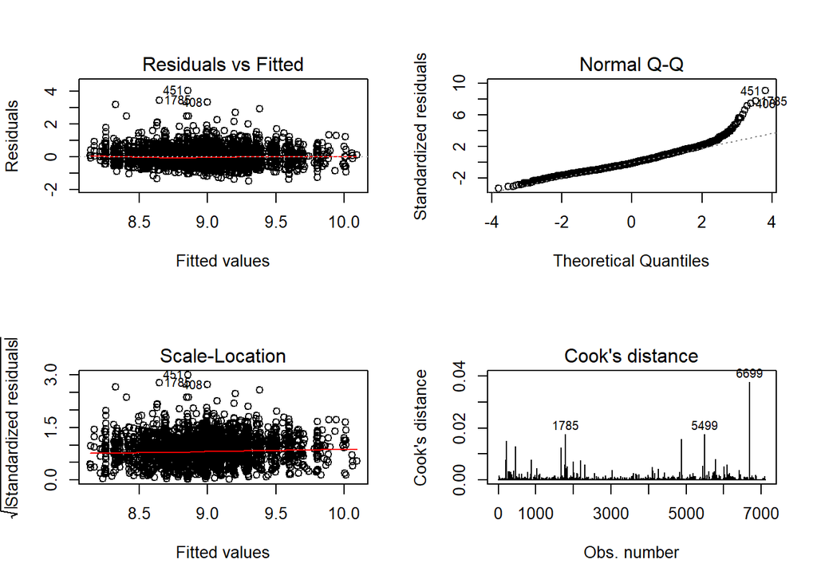

```r
#回归诊断

#检验异方差，正态性和强影响点
par(mfrow=c(2,2))
plot(lm_choi, which=c(1:4))
```

从残差图上可以看到，存在一定的异方差。

从QQ图上可以看到，QQ图的末尾偏离直线，说明部分样本不符合正态性假定。大部分样本点基本符合正态性假定。

库克距离均小于1，认为没有强影响点。

## 5.2 计算vif，检验多重共线性

```r
#计算vif，检验多重共线性
library(car)
vif(lm_choi)
```

```
##              GVIF Df GVIF^(1/(2*Df))
## 地区     1.108896  5        1.010390
## 公司类别 1.084376  7        1.005803
## 学历     1.132355  6        1.010412
## 经验     1.052172  1        1.025755
```

vif值均小于10，可以认为不存在多重共线性的问题。

# 任务六

```r
#评价模型的外样本预测精度
set.seed(1234)
#计算rmse
pred.cv <- function(dat, k){
  ind <- sample(1:k, nrow(dat), replace = TRUE)
  pred_cv <- rep(0, nrow(dat))
  for(i in 1:k){
    ii <- which(ind == i)
    obj <- lm(对数平均薪资~地区+公司类别+学历+经验, data = dat[-ii, ])
    pred_cv[ii] <- predict(obj, df_lm[ii, ])
  }
  rmse <- sqrt(mean((pred_cv-dat$对数平均薪资)^2))
  return(list(pred_cv = pred_cv, rmse = rmse) )

}

set.seed(1234)
pred_cv_lm <- pred.cv(dat = df_lm, k = 5)
#输出rmse
pred_cv_lm$rmse
```

```
## [1] 0.4484058
```

用rmse来评价模型的外样本预测精度，计算得到rmse=0.4484058